# Students Performance in Exams

```r
# import necessary libraries
library(data.table)
library(dplyr)
library(ggplot2)
library(gridExtra)
# load the data
df <- fread("/Users/yesollee/Downloads/StudentsPerformance.csv")
```

# Overview of data

```r
#overview of data
head(df, 5)
```

| gender | race/ethnicity | parental level of education | lunch | test preparation course | math score | reading score | writing score |
| --- | --- | --- | --- | --- | --- | --- | --- |
| female | group B | bachelor's degree | standard | none | 72 | 72 | 74 |
| female | group C | some college | standard | completed | 69 | 90 | 88 |
| female | group B | master's degree | standard | none | 90 | 95 | 93 |
| male | group A | associate's degree | free/reduced | none | 47 | 57 | 44 |
| male | group C | some college | standard | none | 76 | 78 | 75 |

```r
glimpse(df)
```

```
Rows: 1,000
Columns: 8
$ gender                        <chr> "female", "female", "female", "male", "male", "female", …
$ `race/ethnicity`              <chr> "group B", "group C", "group B", "group A", "group C", "…
$ `parental level of education` <chr> "bachelor's degree", "some college", "master's degree", …
$ lunch                         <chr> "standard", "standard", "standard", "free/reduced", "sta…
$ `test preparation course`     <chr> "none", "completed", "none", "none", "none", "none", "co…
$ `math score`                  <int> 72, 69, 90, 47, 76, 71, 88, 40, 64, 38, 58, 40, 65, 78, …
$ `reading score`               <int> 72, 90, 95, 57, 78, 83, 95, 43, 64, 60, 54, 52, 81, 72, …
$ `writing score`               <int> 74, 88, 93, 44, 75, 78, 92, 39, 67, 50, 52, 43, 73, 70, …
```

```r
#find missing values
colSums(is.na(df))
```

```
                     gender              race/ethnicity parental level of education
                          0                           0                           0
                      lunch     test preparation course                  math score
                          0                           0                           0
              reading score               writing score
                          0                           0
```

Since there’s no missing values, let’s dive into data right away.

# Exploratory Data Analysis

## Data preparation

```r
# change column names
names(df) <- c("gender", "race", "parental_edu", "lunch", "test_prep", "math", "reading","writing")

# new feature
df[, total := math + reading + writing]
```

## Insights from Data

```r
# Descriptive statistics by gender
by(df, df$gender, summary)
```

```
df$gender: female
    gender              race           parental_edu          lunch            test_prep
 Length:518         Length:518         Length:518         Length:518         Length:518
 Class :character   Class :character   Class :character   Class :character   Class :character
 Mode  :character   Mode  :character   Mode  :character   Mode  :character   Mode  :character



      math           reading          writing           total
 Min.   :  0.00   Min.   : 17.00   Min.   : 10.00   Min.   : 27.0
 1st Qu.: 54.00   1st Qu.: 63.25   1st Qu.: 64.00   1st Qu.:182.0
 Median : 65.00   Median : 73.00   Median : 74.00   Median :211.0
 Mean   : 63.63   Mean   : 72.61   Mean   : 72.47   Mean   :208.7
 3rd Qu.: 74.00   3rd Qu.: 83.00   3rd Qu.: 82.00   3rd Qu.:236.0
 Max.   :100.00   Max.   :100.00   Max.   :100.00   Max.   :300.0
------------------------------------------------------------------------
df$gender: male
    gender              race           parental_edu          lunch            test_prep
 Length:482         Length:482         Length:482         Length:482         Length:482
 Class :character   Class :character   Class :character   Class :character   Class :character
 Mode  :character   Mode  :character   Mode  :character   Mode  :character   Mode  :character



      math           reading          writing           total
 Min.   : 27.00   Min.   : 23.00   Min.   : 15.00   Min.   : 69.0
 1st Qu.: 59.00   1st Qu.: 56.00   1st Qu.: 53.00   1st Qu.:168.0
 Median : 69.00   Median : 66.00   Median : 64.00   Median :199.0
 Mean   : 68.73   Mean   : 65.47   Mean   : 63.31   Mean   :197.5
 3rd Qu.: 79.00   3rd Qu.: 75.00   3rd Qu.: 73.75   3rd Qu.:228.8
 Max.   :100.00   Max.   :100.00   Max.   :100.00   Max.   :300.0
```

```r
# Average score by gender
gender_avg <- df %>%
  group_by(gender) %>%
  summarize(avg_math = mean(math),
            avg_reading = mean(reading),
            avg_writing = mean(writing),
            avg_total = mean(total)) %>%
  ungroup()

print(gender_avg)
```

| gender | avg_math | avg_reading | avg_writing | avg_total |
| --- | --- | --- | --- | --- |
| female | 63.63320 | 72.60811 | 72.46718 | 208.7085 |
| male | 68.72822 | 65.47303 | 63.31120 | 197.5124 |

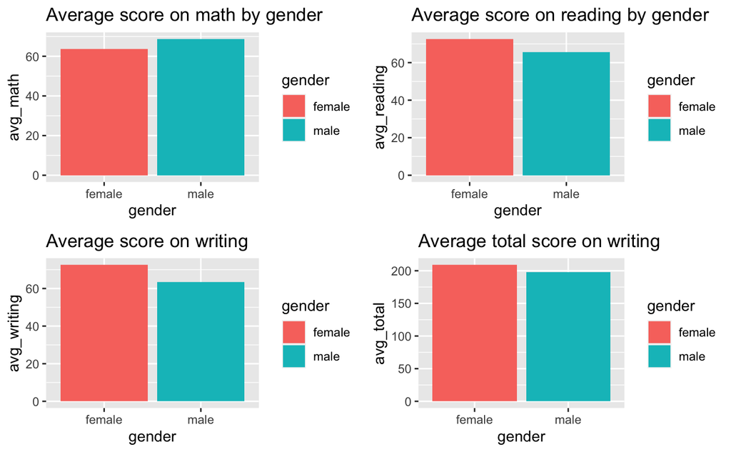

```r
a = ggplot(gender_avg, aes(x=gender, y=avg_math, fill=gender)) +
  geom_col() +
  ggtitle("Average score on math by gender")
b = ggplot(gender_avg, aes(x=gender, y=avg_reading, fill=gender)) +
  geom_col() +
  ggtitle("Average score on reading by gender")
c = ggplot(gender_avg, aes(x=gender, y=avg_writing, fill=gender)) +
  geom_col() +
  ggtitle("Average score on writing")
d = ggplot(gender_avg, aes(x=gender, y=avg_total, fill=gender)) +
  geom_col() +
  ggtitle("Average total score on writing")

grid.arrange(a,b,c,d, nrow=2, ncol=2)
```

As you can see from the plot, male students show higher average score on math. But female students show superior score for the rest.

```r
# descriptive statistics by race group
by(df, df$race, summary)
```

```
df$race: group A
    gender              race           parental_edu          lunch            test_prep
 Length:89          Length:89          Length:89          Length:89          Length:89
 Class :character   Class :character   Class :character   Class :character   Class :character
 Mode  :character   Mode  :character   Mode  :character   Mode  :character   Mode  :character



      math           reading          writing          total
 Min.   : 28.00   Min.   : 23.00   Min.   :19.00   Min.   : 70
 1st Qu.: 51.00   1st Qu.: 53.00   1st Qu.:51.00   1st Qu.:156
 Median : 61.00   Median : 64.00   Median :62.00   Median :184
 Mean   : 61.63   Mean   : 64.67   Mean   :62.67   Mean   :189
 3rd Qu.: 71.00   3rd Qu.: 74.00   3rd Qu.:73.00   3rd Qu.:219
 Max.   :100.00   Max.   :100.00   Max.   :97.00   Max.   :289
------------------------------------------------------------------------
df$race: group B
    gender              race           parental_edu          lunch            test_prep
 Length:190         Length:190         Length:190         Length:190         Length:190
 Class :character   Class :character   Class :character   Class :character   Class :character
 Mode  :character   Mode  :character   Mode  :character   Mode  :character   Mode  :character



      math          reading         writing          total
 Min.   : 8.00   Min.   :24.00   Min.   :15.00   Min.   : 55.0
 1st Qu.:54.00   1st Qu.:56.00   1st Qu.:55.25   1st Qu.:170.0
 Median :63.00   Median :67.00   Median :67.00   Median :195.0
 Mean   :63.45   Mean   :67.35   Mean   :65.60   Mean   :196.4
 3rd Qu.:74.00   3rd Qu.:79.75   3rd Qu.:78.00   3rd Qu.:230.5
 Max.   :97.00   Max.   :97.00   Max.   :96.00   Max.   :290.0
------------------------------------------------------------------------
df$race: group C
    gender              race           parental_edu          lunch            test_prep
 Length:319         Length:319         Length:319         Length:319         Length:319
 Class :character   Class :character   Class :character   Class :character   Class :character
 Mode  :character   Mode  :character   Mode  :character   Mode  :character   Mode  :character



```

[output cut: 24 more lines]

```
df$race: group E
    gender              race           parental_edu          lunch            test_prep
 Length:140         Length:140         Length:140         Length:140         Length:140
 Class :character   Class :character   Class :character   Class :character   Class :character
 Mode  :character   Mode  :character   Mode  :character   Mode  :character   Mode  :character



      math           reading          writing           total
 Min.   : 30.00   Min.   : 26.00   Min.   : 22.00   Min.   : 78.0
 1st Qu.: 64.75   1st Qu.: 63.00   1st Qu.: 62.00   1st Qu.:194.0
 Median : 74.50   Median : 74.00   Median : 72.00   Median :220.5
 Mean   : 73.82   Mean   : 73.03   Mean   : 71.41   Mean   :218.3
 3rd Qu.: 85.00   3rd Qu.: 84.00   3rd Qu.: 80.25   3rd Qu.:247.2
 Max.   :100.00   Max.   :100.00   Max.   :100.00   Max.   :300.0
```

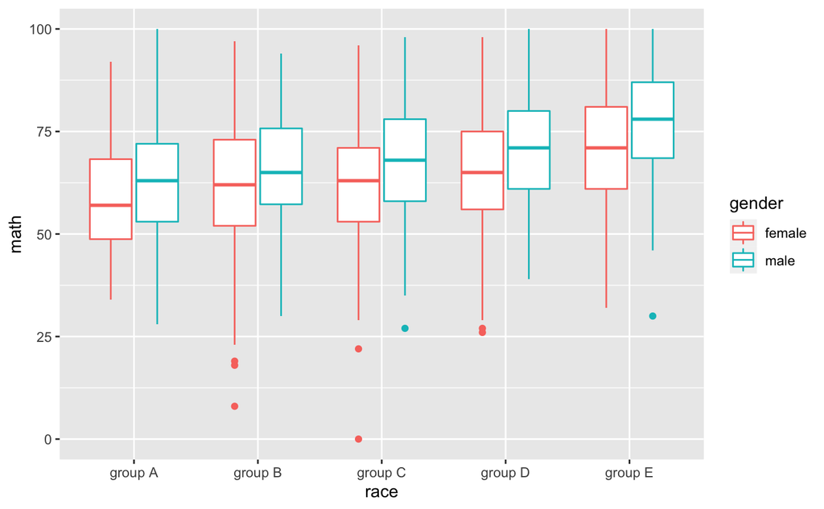

```r
# math score boxplot by race group and gender
ggplot(df, aes(x=race, y=math, color=gender)) +
  geom_boxplot()
```

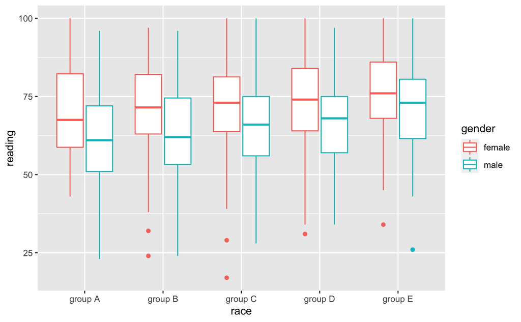

```r
# reading score boxplot by race group and gender
ggplot(df, aes(x=race, y=reading, color=gender)) +
  geom_boxplot()
```

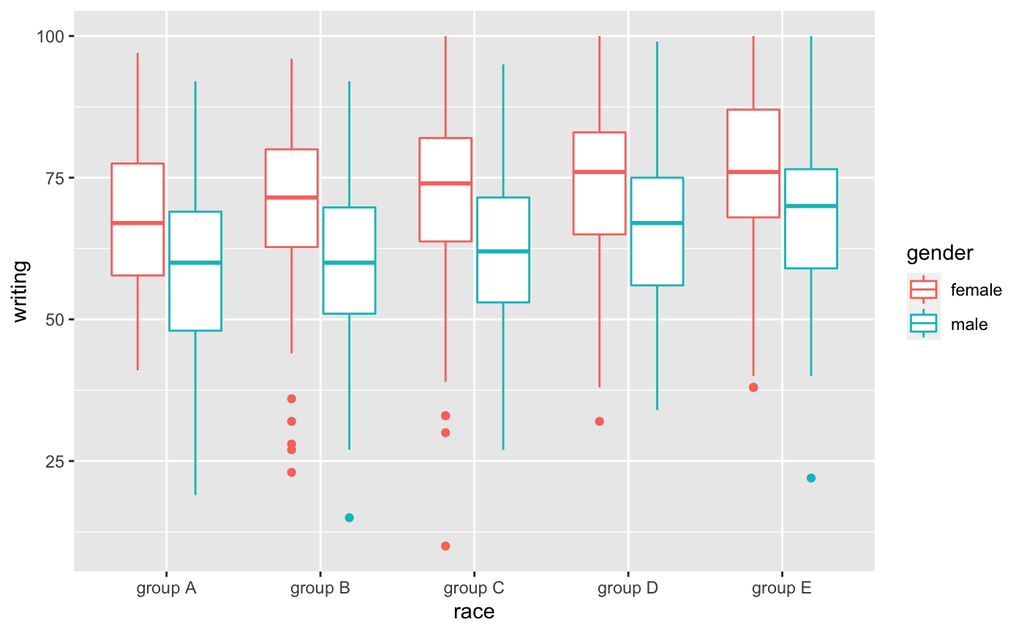

```r
# writing score boxplot by race group and gender
ggplot(df, aes(x=race, y=writing, color=gender)) +
  geom_boxplot()
```

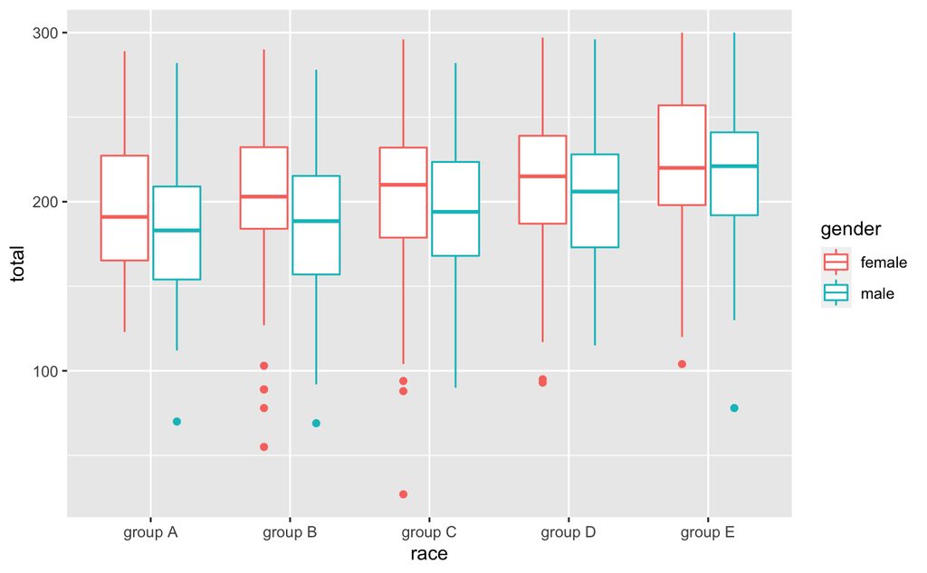

```r
# total boxplot by race group and gender
ggplot(df, aes(x=race, y=total, color=gender)) +
  geom_boxplot()
```

Across all race group, male’s median of math score is higher than that of female. Group E shows the highest median in both gender. Regarding reading, group A shows the lowest median in both gender.

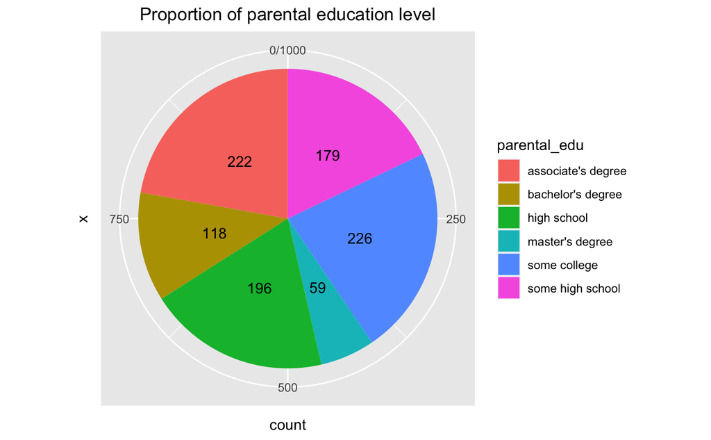

```r
# parental education level
parent_edu_ct <- df[, .N, by=parental_edu]
setnames(parent_edu_ct, "N", "count")

# parental education level count
ggplot(parent_edu_ct, aes(x = "", y = count, fill = parental_edu)) +
     geom_bar(width = 1, stat = "identity") +
     coord_polar(theta = "y", start = 0) +
     geom_text(aes(label = count), position = position_stack(vjust = 0.5)) +
     ggtitle("Proportion of parental education level") +
     theme(plot.title = element_text(hjust = 0.5),
           axis.ticks = element_blank())
```

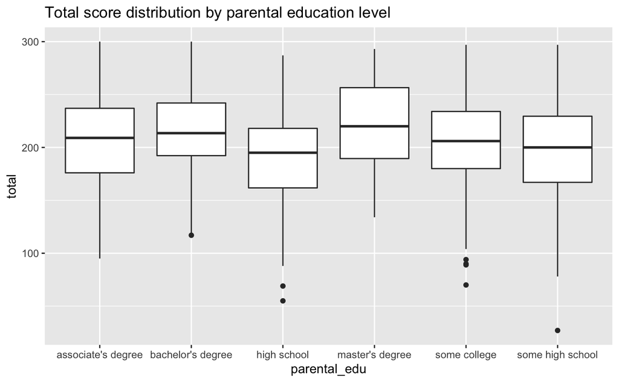

```r
# total score by parent's education level
ggplot(df, aes(x=parental_edu, y=total)) +
  geom_boxplot() +
  ggtitle("Total score distribution by parental education level")
```

Students whose parent have only high school degree showed the lowest median of total score. Students whose parent have master’s degree, on the other hand, showed the highest score. The rest of students have pretty similar median score.

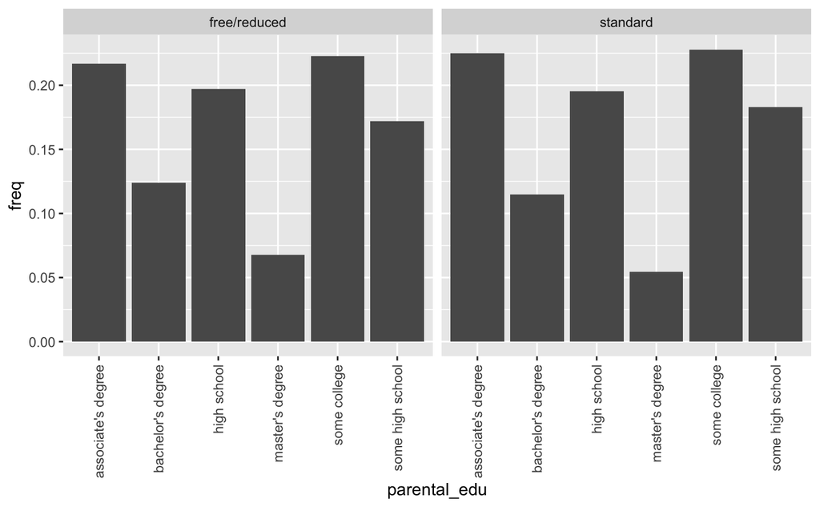

```r
# lunch and parental_edu
lunch_parentedu <-df %>%
  group_by(lunch, parental_edu) %>%
  summarize(n=n()) %>%
  mutate(freq = n / sum(n))
ggplot(lunch_parentedu, aes(x=parental_edu, y=freq)) +
  geom_col() +
  facet_wrap(~lunch) +
  theme(axis.text.x = element_text(angle = 90, vjust = 0.5, hjust=1))
```

```r
df %>%
  group_by(lunch) %>%
  summarize(avg_math = mean(math),
            avg_reading = mean(reading),
            avg_writing = mean(writing),
            avg_total = mean(total))
```

| lunch | avg_math | avg_reading | avg_writing | avg_total |
| --- | --- | --- | --- | --- |
| free/reduced | 58.92113 | 64.65352 | 63.02254 | 186.5972 |
| standard | 70.03411 | 71.65426 | 70.82326 | 212.5116 |

```r
NA
```

I expected parents with higher education level have more income therefore use standard lunch rather than free/reduced. To verify this assumption, I grouped by lunch and checked the proportion of each parental education level. The data indicates that there are not much difference in terms of parental education level within the lunch program. In terms of scores, students who use standard lunch did better on exam across all subjects.

```r
# analysis on test preparation program
df[, .N, by=test_prep]
```

| test_prep | N |
| --- | --- |
| none | 642 |
| completed | 358 |

```r
df %>%
  group_by(test_prep) %>%
    summarize(avg_math = mean(math),
            avg_reading = mean(reading),
            avg_writing = mean(writing),
            avg_total = mean(total))
```

| test_prep | avg_math | avg_reading | avg_writing | avg_total |
| --- | --- | --- | --- | --- |
| completed | 69.69553 | 73.89385 | 74.41899 | 218.0084 |
| none | 64.07788 | 66.53427 | 64.50467 | 195.1168 |

Compared to those didn’t participate test preparation course, students who completed test_prep showed higher grades in all subjects, especially in writing exam.

# Machine Learning using Tree-Based Models

```r
# import necessarry libraries
library(rpart.plot)
library(rpart)
library(Metrics)
library(ipred)
library(caret)
library(randomForest)
library(gbm)
library(fastDummies)

# data splits
set.seed(1)
assignment <- sample(1:3, size = nrow(df), prob = c(7,1.5,1.5), replace = TRUE)

train <- df[assignment == 1, ]
valid <- df[assignment == 2, ]
test <- df[assignment == 3, ]
```

## Regression Tree

```r
# regression tree
# initiate the model
rtree <- rpart(formula = total ~ gender + race + parental_edu + lunch + test_prep,
                     data = train,
                     method = "anova")

print(rtree)
```

```
n= 696

node), split, n, deviance, yval
      * denotes terminal node

 1) root 696 1252955.00 202.5632
   2) lunch=free/reduced 235  435187.40 185.7872
     4) parental_edu=high school,some high school 90  191492.60 171.7556
       8) test_prep=none 52  115090.70 158.5769 *
       9) test_prep=completed 38   55012.32 189.7895 *
     5) parental_edu=associate's degree,bachelor's degree,master's degree,some college 145  214976.20 194.4966 *
   3) lunch=standard 461  717916.90 211.1150
     6) test_prep=none 296  468016.20 203.4223
      12) gender=male 144  216416.00 194.0000 *
      13) gender=female 152  226704.50 212.3487
        26) race=group A,group B,group C 92  122407.60 204.9348 *
        27) race=group D,group E 60   91486.18 223.7167 *
     7) test_prep=completed 165  200960.80 224.9152
      14) parental_edu=high school,some high school 59   63740.85 211.0508 *
      15) parental_edu=associate's degree,bachelor's degree,master's degree,some college 106  119566.70 232.6321 *
```

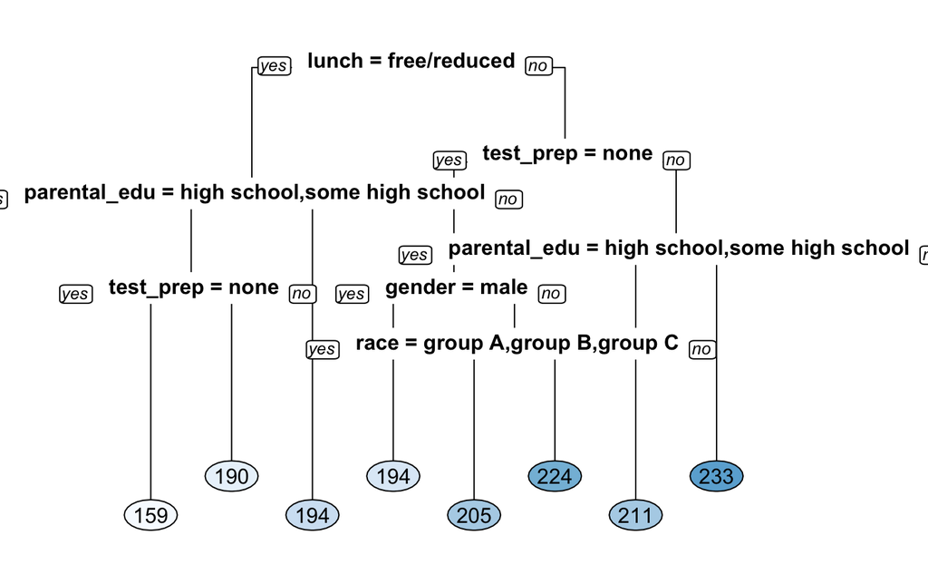

```r
rpart.plot(x = rtree, yesno = 2, type = 0, extra = 0)
```

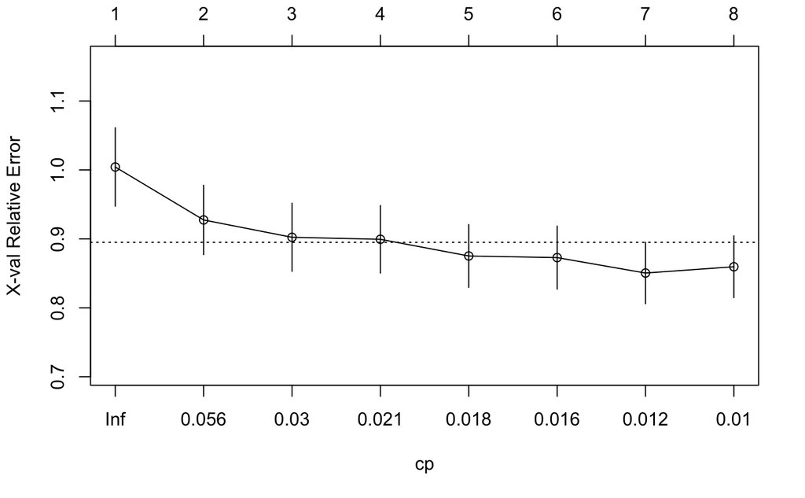

```r
# hyperparameter tuning
# complexity-cost
plotcp(rtree)
```

```r
print(rtree$cptable)
```

```
          CP nsplit rel error    xerror       xstd
1 0.07969235      0 1.0000000 1.0042829 0.05691865
2 0.03905956      1 0.9203076 0.9274551 0.05032079
3 0.02292060      2 0.8812481 0.9023118 0.04939633
4 0.01986958      3 0.8583275 0.8993955 0.04898167
5 0.01707133      4 0.8384579 0.8752077 0.04556883
6 0.01408934      5 0.8213866 0.8728337 0.04570021
7 0.01022441      6 0.8072972 0.8504407 0.04456883
8 0.01000000      7 0.7970728 0.8595794 0.04484842
```

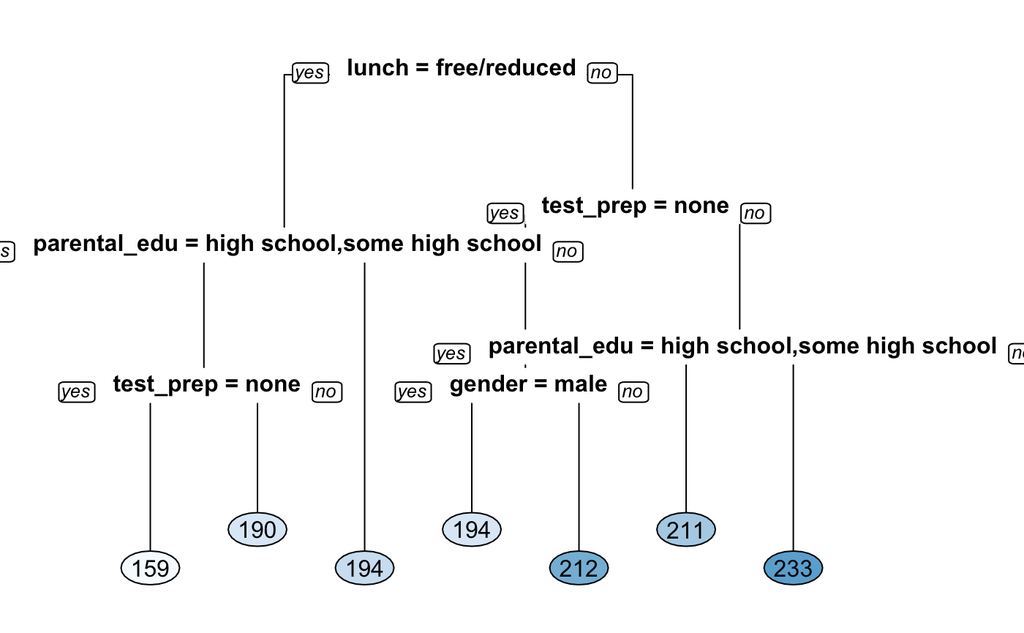

```r
opt_index <- which.min(rtree$cptable[, "xerror"])
cp_opt <- rtree$cptable[opt_index, "CP"]

opt_rtree <- prune(tree = rtree, cp = cp_opt)

rpart.plot(x = opt_rtree, yesno = 2, type = 0, extra = 0)
```

```r
#grid search
minsplit <- seq(1, 4, 1)
maxdepth <- seq(1, 6, 1)

hyper_grid_rt <- expand.grid(minsplit = minsplit, maxdepth = maxdepth)

num_models <- nrow(hyper_grid)
rtree_models <- list()

for (i in 1:num_models) {

    minsplit <- hyper_grid_rt$minsplit[i]
    maxdepth <- hyper_grid_rt$maxdepth[i]

    rtree_models[[i]] <- rpart(formula = total ~ gender + race + parental_edu + lunch + test_prep,
                               data = train,
                               method = "anova",
                               minsplit = minsplit,
                               maxdepth = maxdepth)
}

#evaluate the models
num_models <- length(rtree_models)
rmse_values <- c()

for (i in 1:num_models) {

    model <- rtree_models[[i]]

    pred <- predict(object = model,
                    newdata = valid)

    rmse_values[i] <- rmse(actual = valid$total,
                           predicted = pred)
}

best_rtree <- rtree_models[[which.min(rmse_values)]]

# Print the model paramters of the best model
best_rtree$control
```

```
$minsplit
[1] 2

$minbucket
[1] 1

$cp
[1] 0.01

$maxcompete
[1] 4

$maxsurrogate
[1] 5

$usesurrogate
[1] 2

$surrogatestyle
[1] 0

$maxdepth
[1] 4

$xval
[1] 10
```

```r
# Compute test set RMSE on best_model
rtree_best_pred <- predict(object = best_rtree,
                newdata = test)
rmse(actual = test$total,
     predicted = rtree_best_pred)
```

```
[1] 37.15021
```

## Bagged Trees

```r
# initiate model
set.seed(1)
bagged <- bagging(formula = total ~ gender + race + parental_edu + lunch + test_prep,
                        data = train,
                        coob = TRUE)

print(bagged)
```

```
Bagging regression trees with 25 bootstrap replications

Call: bagging.data.frame(formula = total ~ gender + race + parental_edu +
    lunch + test_prep, data = train, coob = TRUE)

Out-of-bag estimate of root mean squared error:  38.9805
```

```r
# cross validation for bagged trees using caret
ctrl <- trainControl(method = "cv", number = 5)

bagged_caret <- train(total ~ gender + race + parental_edu + lunch + test_prep,
                            data = train,
                            method = "treebag",
                            metric = "RMSE",
                            trControl = ctrl)

print(bagged_caret)
```

```
Bagged CART

696 samples
  5 predictor

No pre-processing
Resampling: Cross-Validated (5 fold)
Summary of sample sizes: 556, 557, 557, 557, 557
Resampling results:

  RMSE      Rsquared   MAE
  38.65716  0.1805647  31.0029
```

```r
bagged_caret_pred_test <- predict(object = bagged_caret,
                newdata = test)

rmse(actual = test$total,
     predicted = bagged_caret_pred_test)
```

```
[1] 36.65334
```

## Random forest

```r
# initiate the model
rf <- randomForest(formula = total ~ gender + race + parental_edu + lunch + test_prep, data = train)
print(rf)
```

```
Call:
 randomForest(formula = total ~ gender + race + parental_edu +      lunch + test_prep, data = train)
               Type of random forest: regression
                     Number of trees: 500
No. of variables tried at each split: 1

          Mean of squared residuals: 1514.59
                    % Var explained: 15.87
```

```r
# predict and compute RMSE
rf_pred <- predict(object = rf, newdata = test)

rmse(actual = test$total,
     predicted = rf_pred)
```

```
[1] 36.81168
```

## Boosted Trees

```r
train_dummies <- dummy_cols(train, remove_selected_columns = TRUE)
colnames(train_dummies)[colnames(train_dummies) == 'race_group A'] <- 'race_A'
colnames(train_dummies)[colnames(train_dummies) == 'race_group B'] <- 'race_B'
colnames(train_dummies)[colnames(train_dummies) == 'race_group C'] <- 'race_C'
colnames(train_dummies)[colnames(train_dummies) == 'race_group D'] <- 'race_D'
colnames(train_dummies)[colnames(train_dummies) == 'race_group E'] <- 'race_E'
colnames(train_dummies)[colnames(train_dummies) == "parental_edu_associate's degree"] <- 'pe_a'
colnames(train_dummies)[colnames(train_dummies) == "parental_edu_bachelor's degree"] <- 'pe_b'
colnames(train_dummies)[colnames(train_dummies) == "parental_edu_high school"] <- 'pe_h'
colnames(train_dummies)[colnames(train_dummies) == "parental_edu_master's degree"] <- 'pe_m'
colnames(train_dummies)[colnames(train_dummies) == "parental_edu_some college"] <- 'pe_c'
colnames(train_dummies)[colnames(train_dummies) == "parental_edu_some high school"] <- 'pe_sh'
colnames(train_dummies)[colnames(train_dummies) == "lunch_free/reduced"] <- 'lunch_fr'

test_dummies <- dummy_cols(test, remove_selected_columns = TRUE)
colnames(test_dummies)[colnames(test_dummies) == 'race_group A'] <- 'race_A'
colnames(test_dummies)[colnames(test_dummies) == 'race_group B'] <- 'race_B'
colnames(test_dummies)[colnames(test_dummies) == 'race_group C'] <- 'race_C'
colnames(test_dummies)[colnames(test_dummies) == 'race_group D'] <- 'race_D'
colnames(test_dummies)[colnames(test_dummies) == 'race_group E'] <- 'race_E'
colnames(test_dummies)[colnames(test_dummies) == "parental_edu_associate's degree"] <- 'pe_a'
colnames(test_dummies)[colnames(test_dummies) == "parental_edu_bachelor's degree"] <- 'pe_b'
colnames(test_dummies)[colnames(test_dummies) == "parental_edu_high school"] <- 'pe_h'
colnames(test_dummies)[colnames(test_dummies) == "parental_edu_master's degree"] <- 'pe_m'
colnames(test_dummies)[colnames(test_dummies) == "parental_edu_some college"] <- 'pe_c'
colnames(test_dummies)[colnames(test_dummies) == "parental_edu_some high school"] <- 'pe_sh'
colnames(test_dummies)[colnames(test_dummies) == "lunch_free/reduced"] <- 'lunch_fr'

btree <- gbm(formula = total ~ gender_female + gender_male + race_A + race_B + race_C +
              race_D + race_E + pe_a + pe_b + pe_h + pe_m + pe_c + pe_sh + lunch_fr +
              lunch_standard + test_prep_completed + test_prep_none,
              data = train_dummies,
              distribution = "gaussian",
              n.trees = 1000,
              interaction.depth = 2,
              shrinkage = 0.001
             )

print(btree)
```

```
gbm(formula = total ~ gender_female + gender_male + race_A +
    race_B + race_C + race_D + race_E + pe_a + pe_b + pe_h +
    pe_m + pe_c + pe_sh + lunch_fr + lunch_standard + test_prep_completed +
    test_prep_none, distribution = "gaussian", data = train_dummies,
    n.trees = 1000, interaction.depth = 2, shrinkage = 0.001)
A gradient boosted model with gaussian loss function.
1000 iterations were performed.
There were 17 predictors of which 16 had non-zero influence.
```

```r
# predict
btree_pred <- predict(object=btree, newdata=test_dummies)
```

```
Using 1000 trees...
```

```r
rmse(actual = test_dummies$total,
     predicted = btree_pred)
```

```
[1] 37.75285
```

# Conclusion

Using various tree-based model, I computed RMSE to evaluate the models. RMSE of each models are followings:

- Regression Tree: 37.15021
- Bagged Tree: 36.65334
- Random Forest: 36.81168
- Boosted Trees: 37.75285

The bagged tree model shows the lowest RMSE, in other words, the model performs best for the current dataset.